# r-for-data-science

#### 4

> Make a scatterplot of hwy versus cyl.

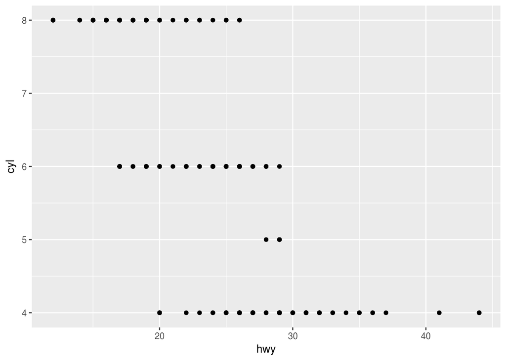

```r
ggplot(data = ggplot2::mpg) +
  geom_point(mapping = aes(x = hwy, y = cyl))
```

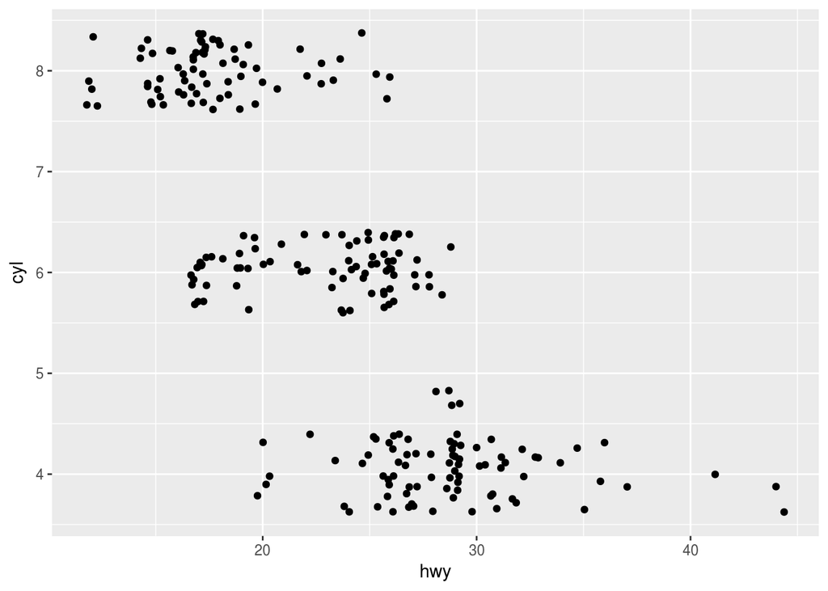

```r
ggplot(data = ggplot2::mpg) +
  geom_jitter(mapping = aes(x = hwy, y = cyl))
```

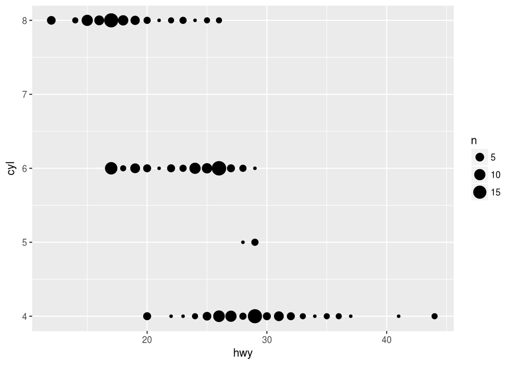

```r
ggplot(data = ggplot2::mpg) +
  geom_count(mapping = aes(x = hwy, y = cyl))
```

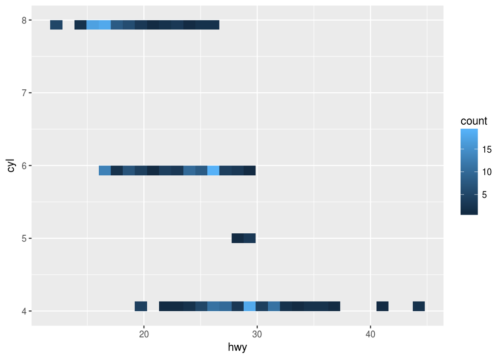

```r
ggplot(data = ggplot2::mpg) +
  geom_bin2d(mapping = aes(x = hwy, y = cyl))
```

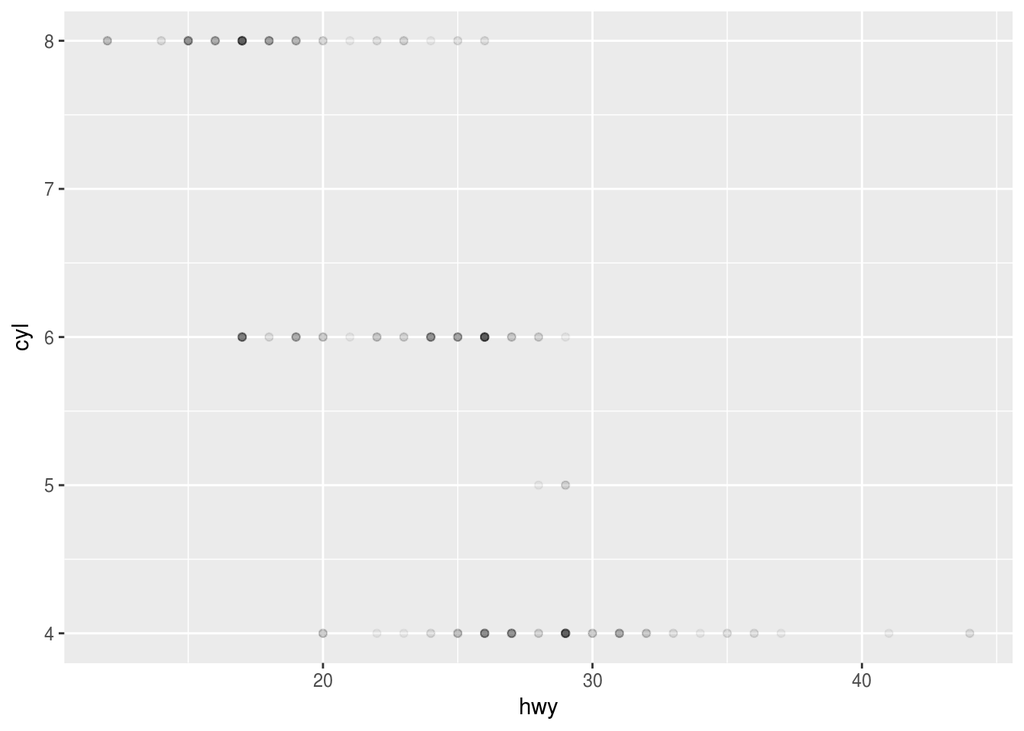

```r
ggplot(data = ggplot2::mpg) +
  geom_point(mapping = aes(x = hwy, y = cyl), alpha = 0.05)
```

#### 5

> What happens if you make a scatterplot of class versus drv? Why is the plot not useful?

`class` and `drv` are both categorical variables.

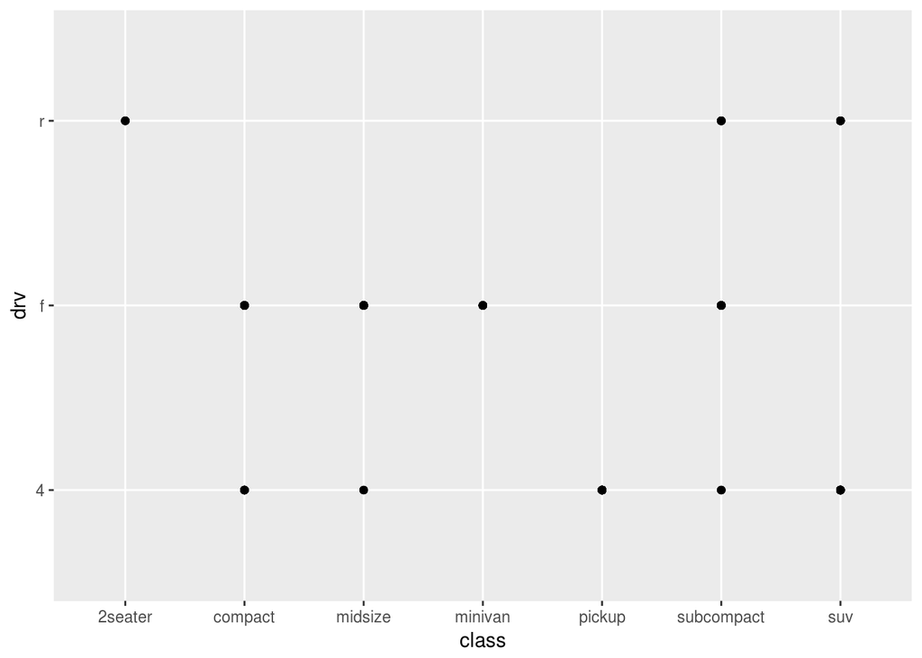

```r
ggplot(data = ggplot2::mpg) +
  geom_point(mapping = aes(x = class, y = drv))
```

## Aesthetic Mappings

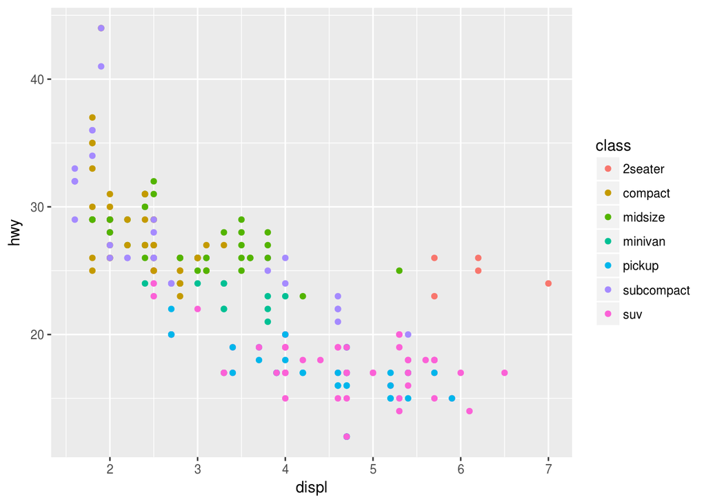

```r
ggplot(data = ggplot2::mpg) +
  geom_point(mapping = aes(x = displ, y = hwy, color = class))
```

### Exercises

#### 1

```r
ggplot2::mpg
```

```
## # A tibble: 234 x 11
##    manufacturer      model displ  year   cyl      trans   drv   cty   hwy
##           <chr>      <chr> <dbl> <int> <int>      <chr> <chr> <int> <int>
##  1         audi         a4   1.8  1999     4   auto(l5)     f    18    29
##  2         audi         a4   1.8  1999     4 manual(m5)     f    21    29
##  3         audi         a4   2.0  2008     4 manual(m6)     f    20    31
##  4         audi         a4   2.0  2008     4   auto(av)     f    21    30
##  5         audi         a4   2.8  1999     6   auto(l5)     f    16    26
##  6         audi         a4   2.8  1999     6 manual(m5)     f    18    26
##  7         audi         a4   3.1  2008     6   auto(av)     f    18    27
##  8         audi a4 quattro   1.8  1999     4 manual(m5)     4    18    26
##  9         audi a4 quattro   1.8  1999     4   auto(l5)     4    16    25
## 10         audi a4 quattro   2.0  2008     4 manual(m6)     4    20    28
## # ... with 224 more rows, and 2 more variables: fl <chr>, class <chr>
```

#### 2

> Which variables in mpg are categorical? Which variables are continuous? (Hint: type ?mpg to read the documentation for the dataset.) How can you see this information when you run mpg?

```r
str(ggplot2::mpg)
```

```
## Classes 'tbl_df', 'tbl' and 'data.frame':    234 obs. of  11 variables:
##  $ manufacturer: chr  "audi" "audi" "audi" "audi" ...
##  $ model       : chr  "a4" "a4" "a4" "a4" ...
##  $ displ       : num  1.8 1.8 2 2 2.8 2.8 3.1 1.8 1.8 2 ...
##  $ year        : int  1999 1999 2008 2008 1999 1999 2008 1999 1999 2008 ...
##  $ cyl         : int  4 4 4 4 6 6 6 4 4 4 ...
##  $ trans       : chr  "auto(l5)" "manual(m5)" "manual(m6)" "auto(av)" ...
##  $ drv         : chr  "f" "f" "f" "f" ...
##  $ cty         : int  18 21 20 21 16 18 18 18 16 20 ...
##  $ hwy         : int  29 29 31 30 26 26 27 26 25 28 ...
##  $ fl          : chr  "p" "p" "p" "p" ...
##  $ class       : chr  "compact" "compact" "compact" "compact" ...
```

#### 3

> Map a continuous variable to color, size, and shape. How do these aesthetics behave differently for categorical versus continuous variables?

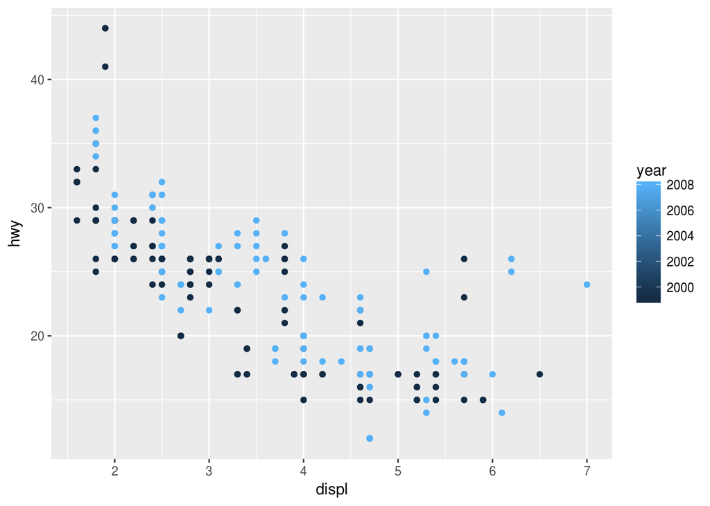

```r
ggplot(data = ggplot2::mpg) +
  geom_point(mapping = aes(x = displ, y = hwy, color = year))
```

#### 4

> What happens if you map the same variable to multiple aesthetics?

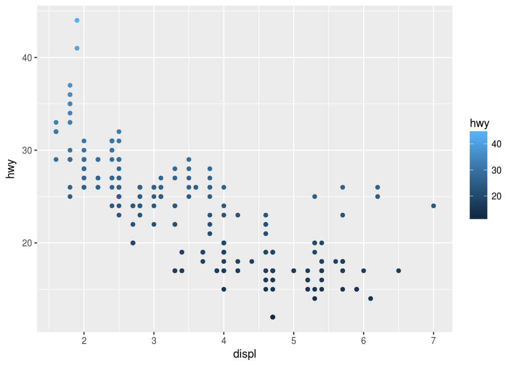

```r
ggplot(data = ggplot2::mpg) +
  geom_point(mapping = aes(x = displ, y = hwy, color = hwy))
```

#### 5

> What does the stroke aesthetic do? What shapes does it work with? (Hint: use ?geom_point.)

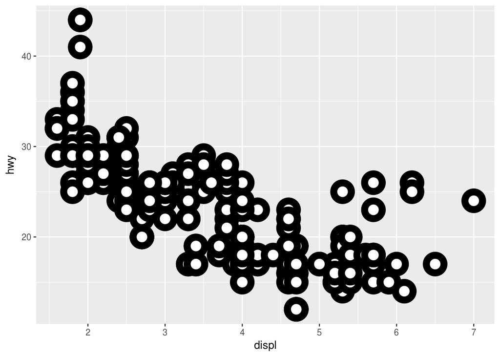

```r
ggplot(data = ggplot2::mpg) +
  geom_point(mapping = aes(x = displ, y = hwy), shape = 21, colour = "black", fill = "white", size = 5, stroke = 5)
```

#### 6

> What happens if you map an aesthetic to something other than a variable name, like aes(color = displ < 5)?

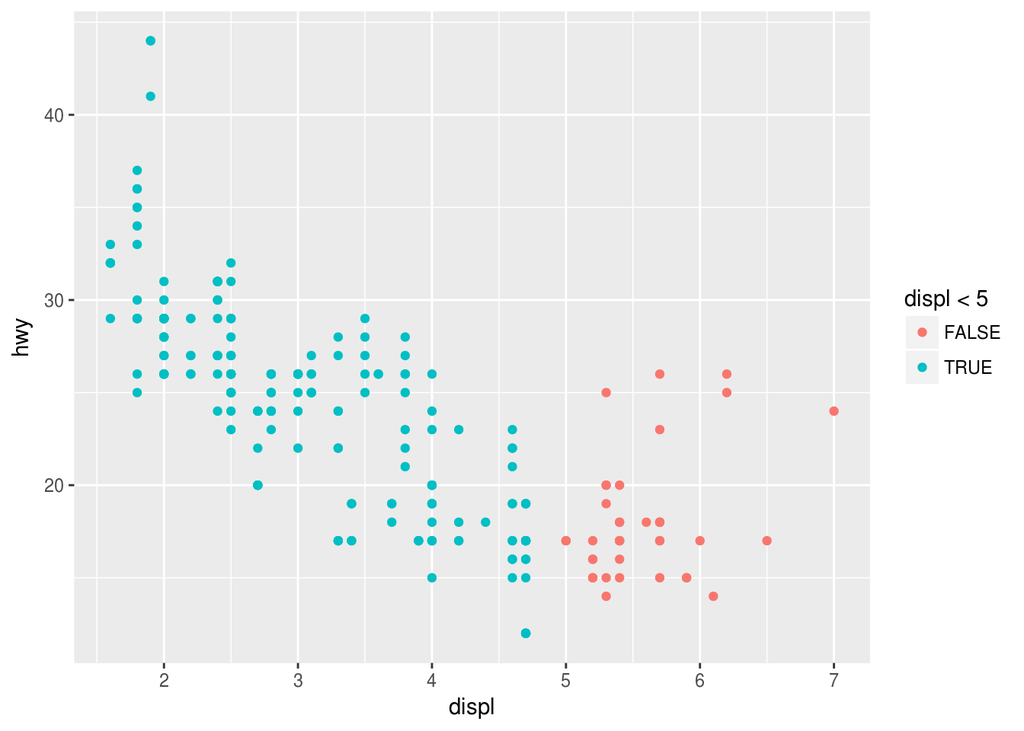

```r
ggplot(data = ggplot2::mpg) +
  geom_point(mapping = aes(x = displ, y = hwy, color = displ < 5))
```

## Common Problems

```r
#ggplot(data = mpg)
#  + geom_point(mapping = aes(x = displ, y = hwy))
```

## Facets

### Highway Mileage (per Gallon) by Engine Displacement (in Litres), By Car Type

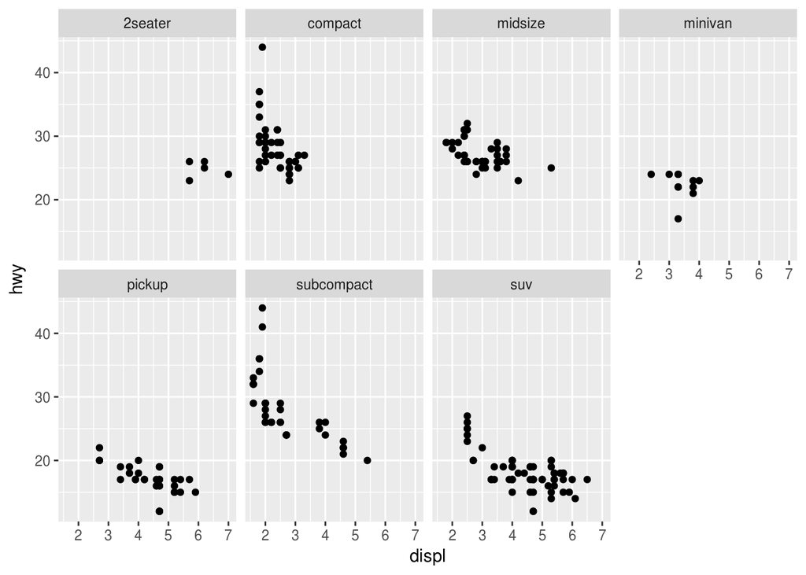

```r
ggplot(data = ggplot2::mpg) +
  geom_point(mapping = aes(x = displ, y = hwy)) +
  facet_wrap(~ class, nrow = 2)
```

### Highway Mileage (per Gallon) by Engine Displacement (in Litres), By Drive Type, By Number of Cylinders

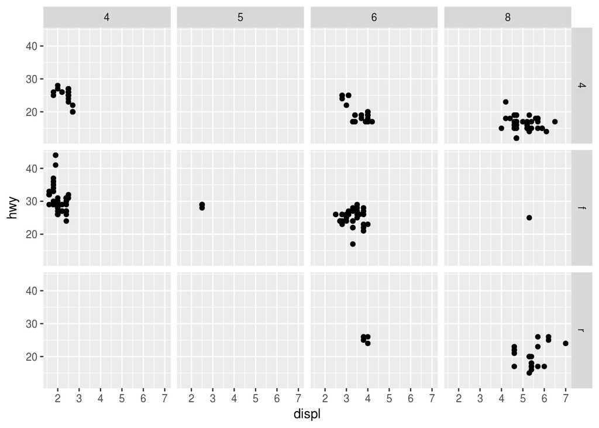

```r
ggplot(data = ggplot2::mpg) +
  geom_point(mapping = aes(x = displ, y = hwy)) +
  facet_grid(drv ~ cyl)
```

## Highway Mileage (per Gallon) by Engine Displacement (in Litres), By Number of Cylinders

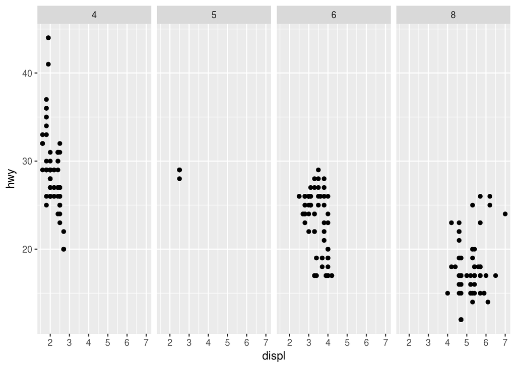

```r
ggplot(data = ggplot2::mpg) +
  geom_point(mapping = aes(x = displ, y = hwy)) +
  facet_grid(. ~ cyl)
```

## Exercises

#### 1

> What happens if you facet on a continuous variable?

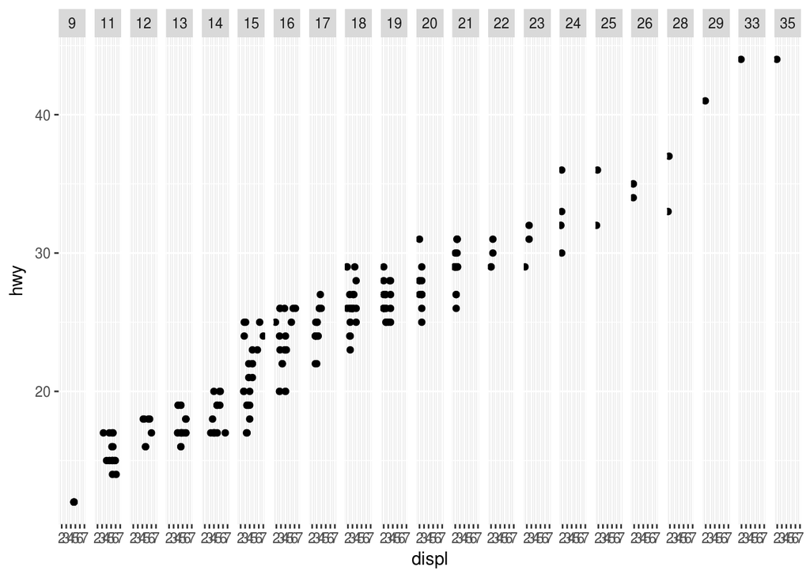

```r
ggplot(data = ggplot2::mpg) +
  geom_point(mapping = aes(x = displ, y = hwy)) +
  facet_grid(. ~ cty)
```

#### 2

> What do the empty cells in a plot with facet_grid(drv ~ cyl) mean? How do they relate to this plot?

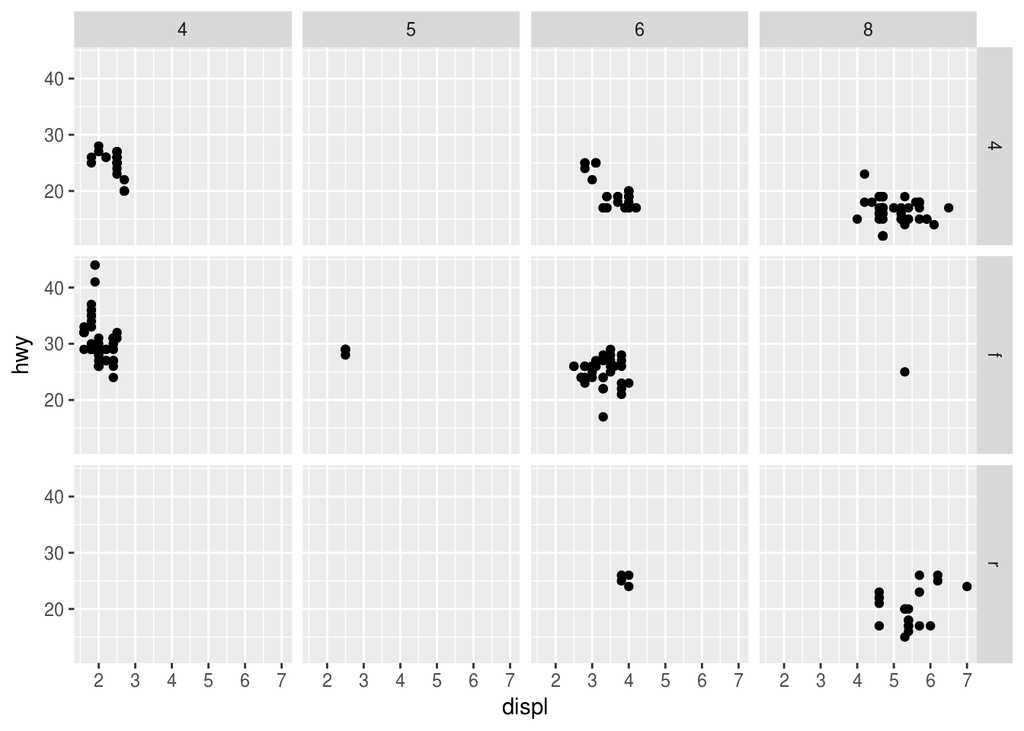

```r
ggplot(data = ggplot2::mpg) +
  geom_point(mapping = aes(x = displ, y = hwy)) +
  facet_grid(drv ~ cyl)
```

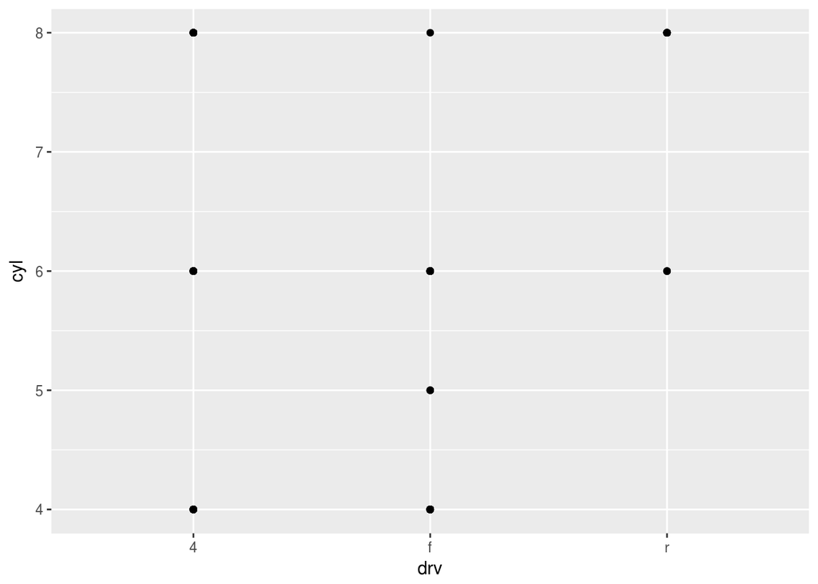

```r
ggplot(data = mpg) +
  geom_point(mapping = aes(x = drv, y = cyl))
```

#### 3

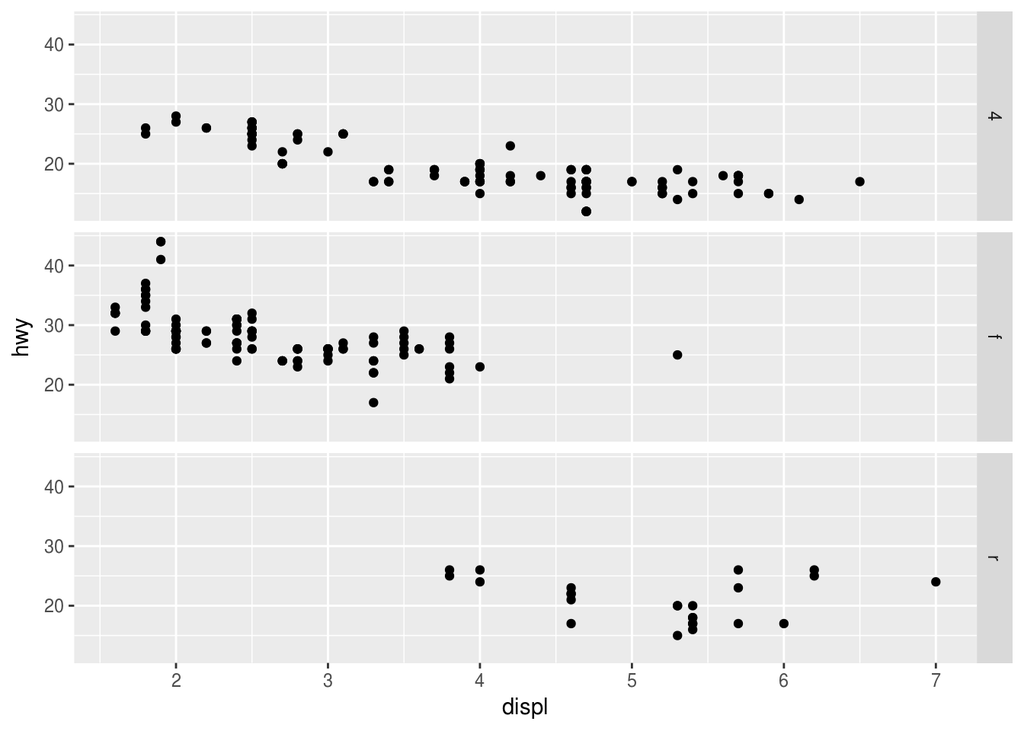

```r
ggplot(data = mpg) +
  geom_point(mapping = aes(x = displ, y = hwy)) +
  facet_grid(drv ~ .)
```

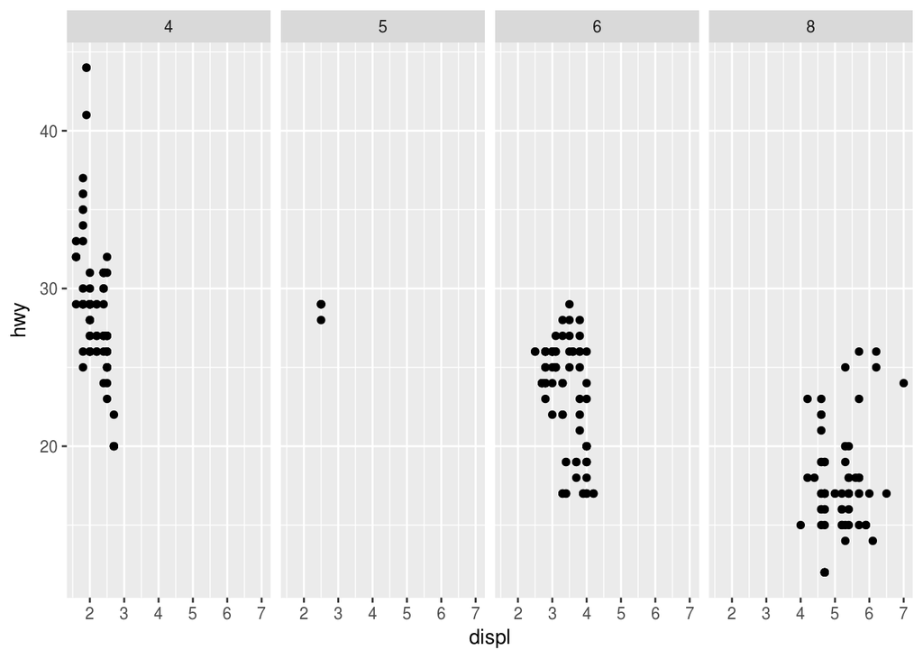

```r
ggplot(data = mpg) +
  geom_point(mapping = aes(x = displ, y = hwy)) +
  facet_grid(. ~ cyl)
```

#### 4

> Take the first faceted plot in this section:

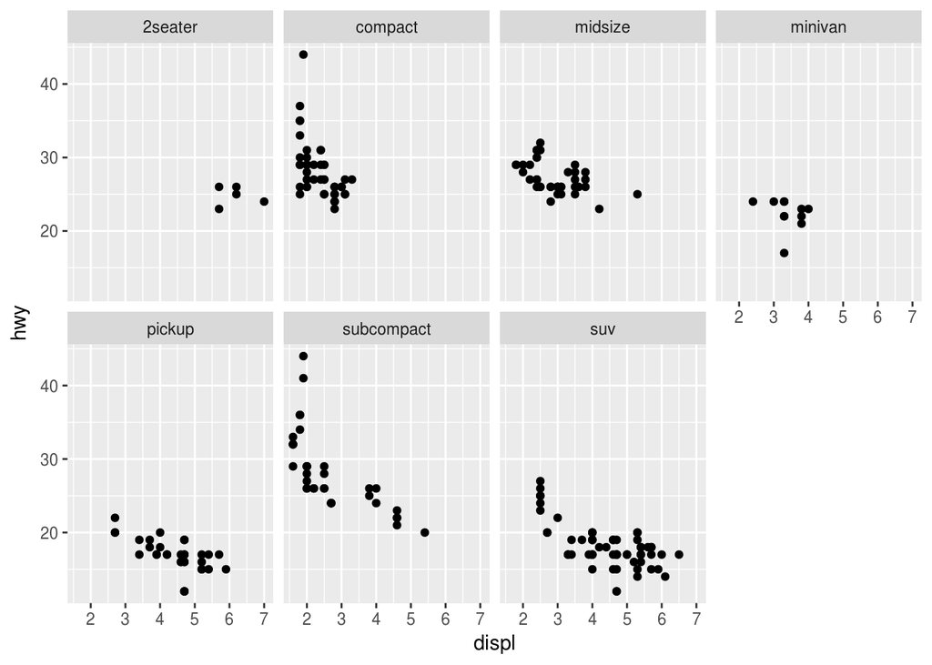

```r
ggplot(data = mpg) +
  geom_point(mapping = aes(x = displ, y = hwy)) +
  facet_wrap(~ class, nrow = 2)
```

> What are the advantages to using faceting instead of the color aesthetic? What are the disadvantages? How might the balance change if you had a larger dataset?

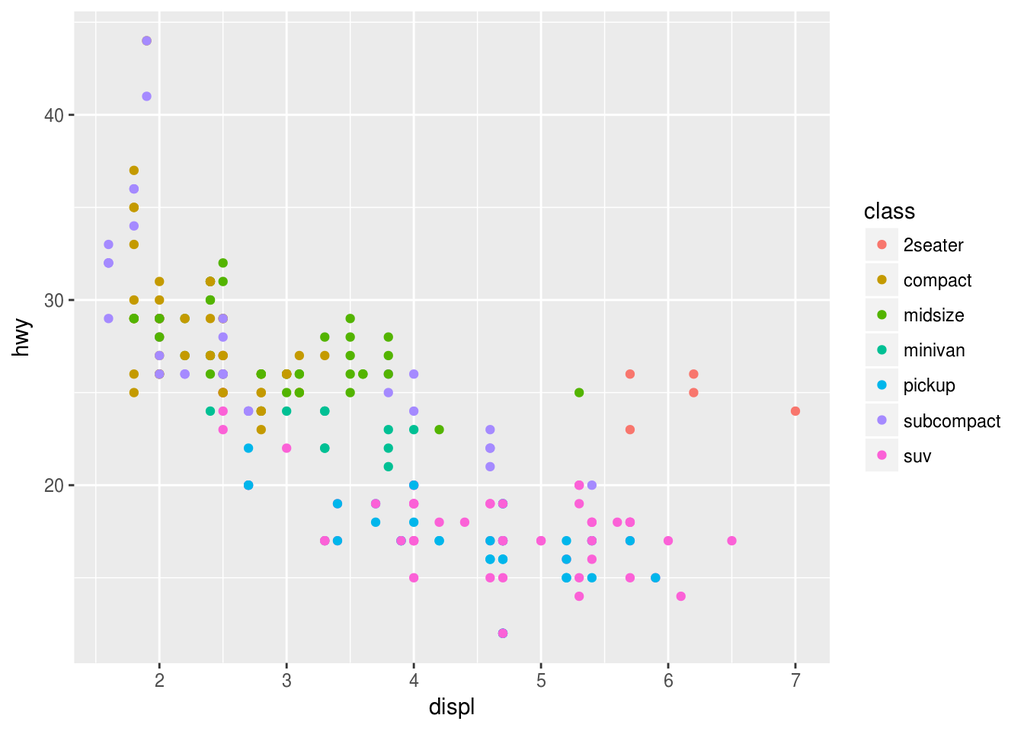

```r
ggplot(data = ggplot2::mpg) +
  geom_point(mapping = aes(x = displ, y = hwy, color = class))
```

#### 5

```r
?facet_wrap
```